# Analyzing Individual BGG Users

Phil Henrickson

2022-01-02

# **hej989’s** BoardGameGeek Collection

This notebook contains a set of analyses for the selected user’s boardgamegeek collection. The bulk of the analysis is focused on building a user-specific predictive model to predict the games that hej989 is likely to own. This enables to ask questions like, based on the games the user currently owns, what games are a good fit for their collection? What upcoming games are they likely to purchase?

This analysis is based on data from BoardGameGeek that was last updated on **2021-12-20.**

# 1 Collection Overview

We can look at a basic description of the number of games that the user owns, has rated, has previously owned, etc.

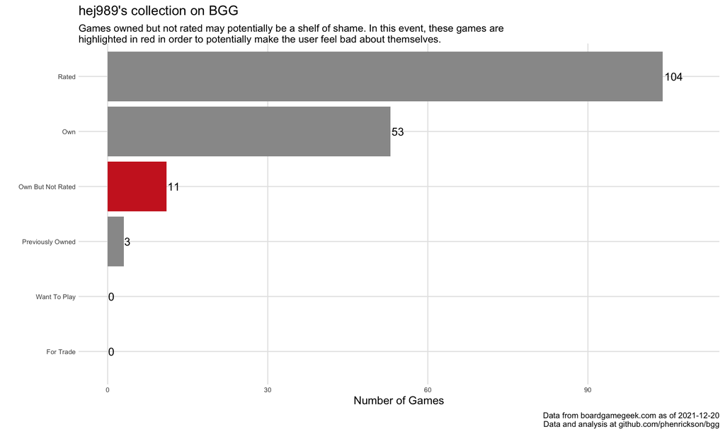

What years has the user owned/rated games from? While we can’t see when a user added or removed a game from their collection, we can look at their collection by the years in which their games were published.

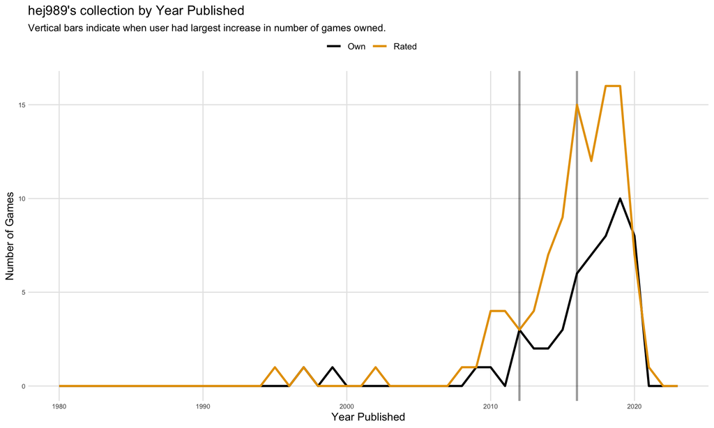

## 1.1 What types of games does hej989 own?

We can look at the most frequent types of categories, mechanics, designers, and artists that appear in a user’s collection.

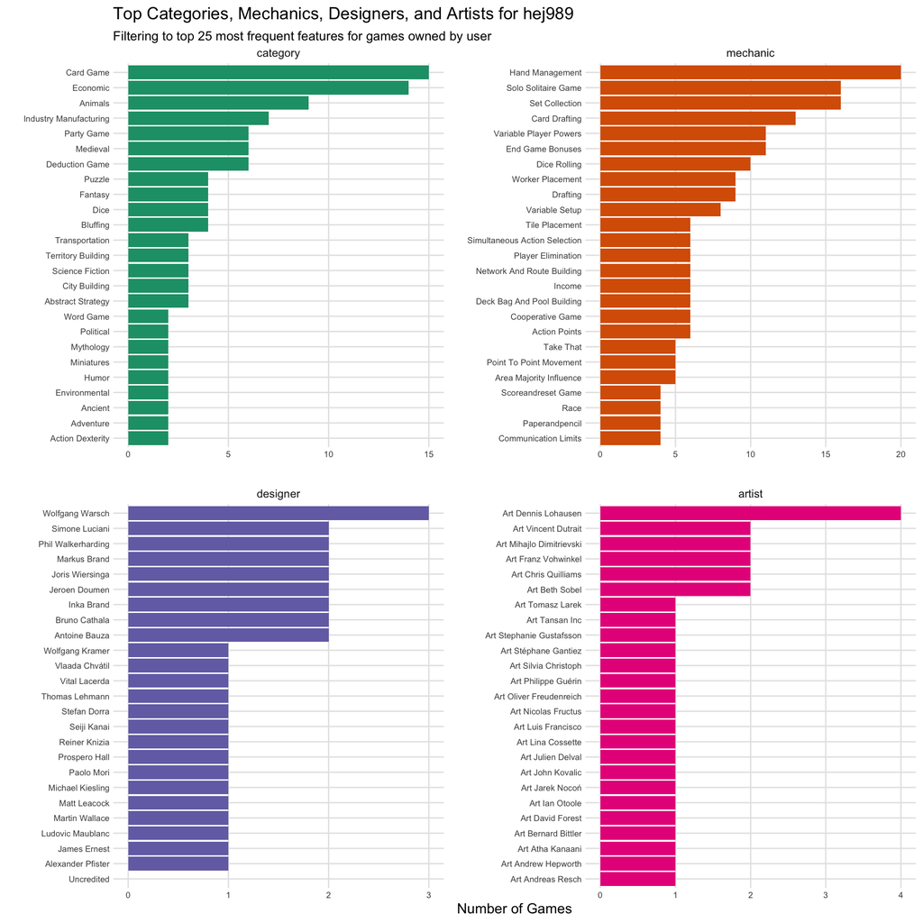

# 2 Modeling **hej989’s** Collection

| username | dataset | period | games_owned | games_rated | games_played |
| --- | --- | --- | --- | --- | --- |
| hej989 | training | published before 2020 | 45 | 96 | 103 |
| hej989 | test | published 2020 or later | 8 | 8 | 12 |

There are two main (binary) outcomes we will be modeling for the user.

The first, **own** refers to whether the user currently lists a game as owned in their collection. The second, **played** refers to whether the user currently owns, has rated, or previously owned a game. This means the latter will generally have a larger list of games, but may still be a useful category to examine for people who play lots of games without necessarily owning them.

We will train predictive models to learn the probability that the user will own or play individual games based on their features.

## 2.1 Coefficients for hej989

We can examine coefficients from the trained modes, which are penalized logistic regressions fit to our two main outcomes. Positive values indicate that a feature increases a user’s probabilility of owning/rating a game, while negative values indicate a feature decreases the probability.

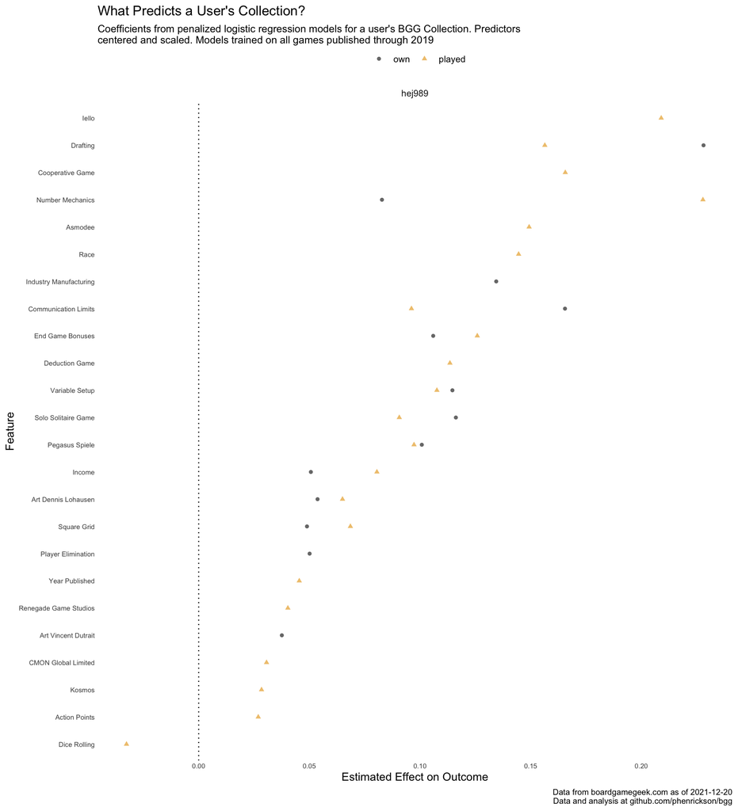

## 2.2 Visualizing Predictors for hej989’s Collection

Why did the model identify these features? We can make density plots of the important features for predicting whether the user owned a game. Blue indicates the density for games owned by the user, while grey indicates the density for games not owned by the user.

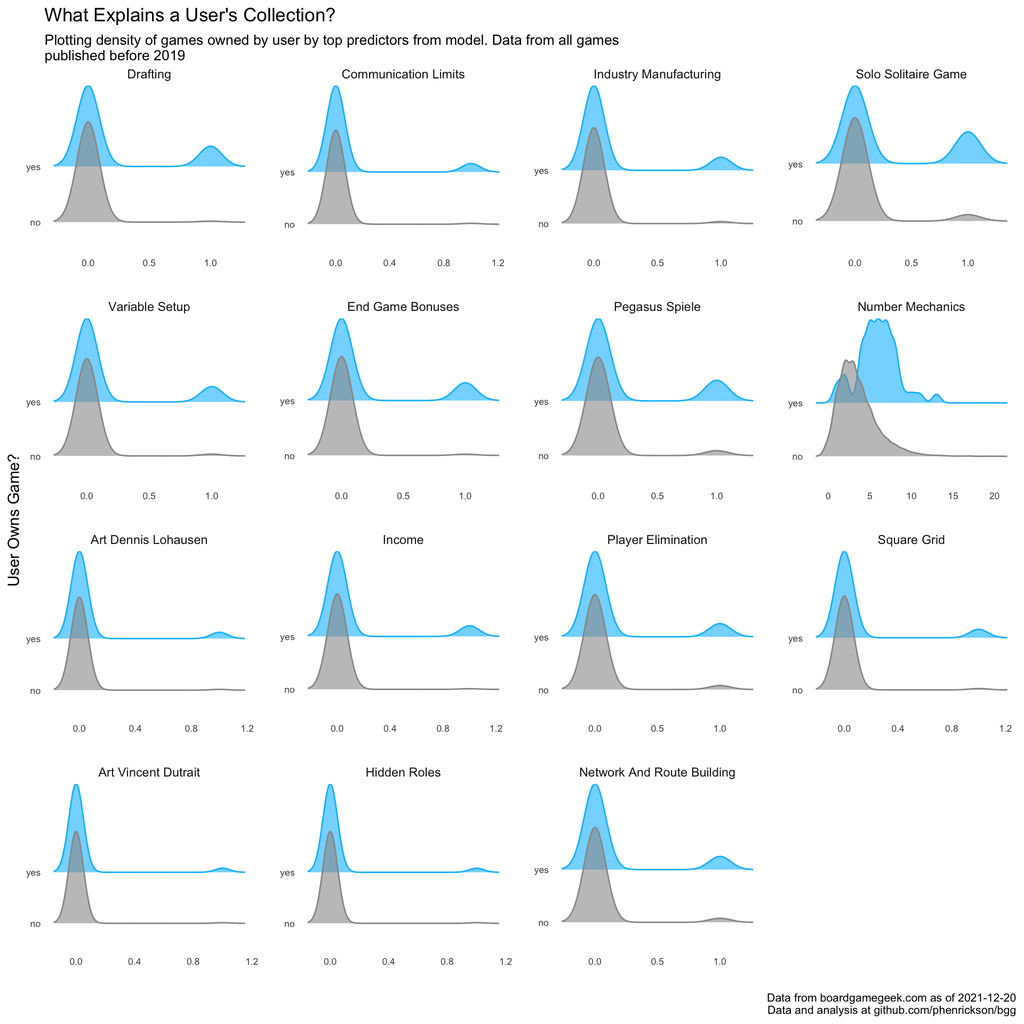

Binary predictors can be difficult to see with this visualization, so we can also directly examine the percentage of games in a user’s collection with a predictor vs the percentage of all games with that predictor.

| username | Feature | % of Games with Feature In_Collection | % of Games with Feature All_Games | Ratio |
| --- | --- | --- | --- | --- |
| hej989 | Drafting | 20.0% | 0.9% | 21.1 |
| hej989 | Income | 11.1% | 0.7% | 16.4 |
| hej989 | End Game Bonuses | 17.8% | 1.2% | 14.8 |
| hej989 | Communication Limits | 8.9% | 1.0% | 9.3 |
| hej989 | Variable Setup | 15.6% | 1.8% | 8.5 |
| hej989 | Industry Manufacturing | 13.3% | 2.0% | 6.6 |
| hej989 | Square Grid | 8.9% | 1.4% | 6.4 |
| hej989 | Hidden Roles | 4.4% | 0.7% | 6.2 |
| hej989 | Solo Solitaire Game | 28.9% | 5.8% | 5.0 |
| hej989 | Pegasus Spiele | 20.0% | 4.7% | 4.2 |
| hej989 | Player Elimination | 13.3% | 4.0% | 3.3 |
| hej989 | Network And Route Building | 13.3% | 4.1% | 3.3 |
| hej989 | Word Game | 4.4% | 1.8% | 2.5 |
| hej989 | Prehistoric | 2.2% | 1.0% | 2.2 |
| hej989 | Party Game | 13.3% | 8.5% | 1.6 |
| hej989 | Medieval | 8.9% | 6.3% | 1.4 |
| hej989 | Puzzle | 4.4% | 3.4% | 1.3 |
| hej989 | City Building | 4.4% | 4.3% | 1.0 |
| hej989 | Trains | 2.2% | 2.2% | 1.0 |
| hej989 | Action Dexterity | 4.4% | 4.8% | 0.9 |
| hej989 | Racing | 2.2% | 2.8% | 0.8 |
| hej989 | Horror | 2.2% | 4.0% | 0.6 |
| hej989 | Negotiation | 2.2% | 3.7% | 0.6 |
| hej989 | Trivia | 0.0% | 1.8% | 0.0 |
| hej989 | Mafia | 0.0% | 0.7% | 0.0 |

# 3 Assess Model’s Performance on Training Set

Before predicting games in upcoming years, we can examine how well the model did and what games it liked in the training set. In this case, we used resampling techniques (cross validation) to ensure that the model had not seen a game before making its predictions.

## 3.1 Separation Plot

An easy way to examine the performance of classification model is to view a separation plot. We plot the predicted probabilities from the model for every game (from resampling) from lowest to highest. We then overlay a blue line for any game that the user does own. A good classifier is one that is able to *separate* the blue (games owned by the user) from the white (games not owned by the user), with most of the blue occurring at the highest probabilities (right side of the chart).

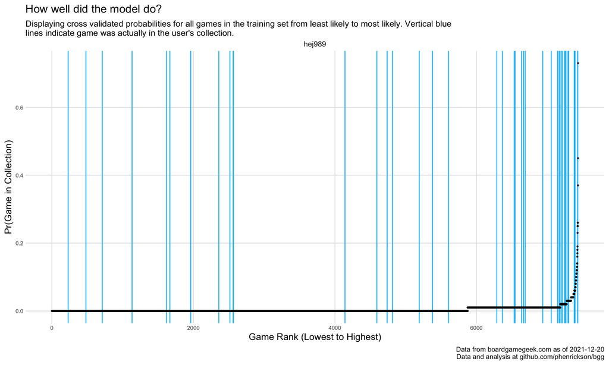

## 3.2 Top Games for **hej989** from Training Set

We can display this information in table form, displaying the 100 games with the highest probability of ownership, adding a blue line when the user does own the game.

| username | yearpublished | game_id | name | pred_played | pred_own | actual_played | actual_own |
| --- | --- | --- | --- | --- | --- | --- | --- |
| hej989 | 2019 | 283863 | The Magnificent | 0.93 | 0.73 | 0 | 0 |
| hej989 | 2018 | 244711 | Newton | 0.89 | 0.45 | 0 | 0 |
| hej989 | 2018 | 199792 | Everdell | 0.30 | 0.37 | 1 | 0 |
| hej989 | 2019 | 251247 | Barrage | 0.32 | 0.26 | 1 | 1 |
| hej989 | 2016 | 167791 | Terraforming Mars | 0.43 | 0.26 | 1 | 1 |
| hej989 | 2015 | 181687 | The Pursuit of Happiness | 0.28 | 0.25 | 1 | 1 |
| hej989 | 2014 | 146886 | La Granja | 0.21 | 0.25 | 0 | 0 |
| hej989 | 2019 | 281259 | The Isle of Cats | 0.44 | 0.23 | 0 | 0 |
| hej989 | 2019 | 270971 | Era: Medieval Age | 0.60 | 0.19 | 0 | 0 |
| hej989 | 2014 | 156129 | Deception: Murder in Hong Kong | 0.44 | 0.18 | 0 | 0 |
| hej989 | 2018 | 205896 | Rising Sun | 0.75 | 0.17 | 0 | 0 |
| hej989 | 2017 | 220308 | Gaia Project | 0.26 | 0.16 | 1 | 0 |
| hej989 | 2018 | 247763 | Underwater Cities | 0.11 | 0.14 | 0 | 0 |
| hej989 | 2016 | 72321 | The Networks | 0.32 | 0.14 | 0 | 0 |
| hej989 | 2016 | 155821 | Inis | 0.11 | 0.13 | 0 | 0 |
| hej989 | 2019 | 283294 | Yukon Airways | 0.31 | 0.13 | 0 | 0 |
| hej989 | 2019 | 261342 | Old West Empresario | 0.07 | 0.13 | 0 | 0 |
| hej989 | 2019 | 260710 | Amul | 0.18 | 0.12 | 0 | 0 |
| hej989 | 2017 | 209778 | Magic Maze | 0.08 | 0.12 | 0 | 0 |
| hej989 | 2017 | 217861 | Paper Tales | 0.31 | 0.12 | 0 | 0 |
| hej989 | 2012 | 63628 | The Manhattan Project | 0.19 | 0.12 | 0 | 0 |
| hej989 | 2012 | 107635 | Kairo | 0.14 | 0.11 | 0 | 0 |
| hej989 | 2014 | 153938 | Camel Up | 0.23 | 0.11 | 0 | 0 |
| hej989 | 2007 | 31260 | Agricola | 0.06 | 0.11 | 0 | 0 |
| hej989 | 2015 | 172996 | The King Is Dead | 0.05 | 0.10 | 0 | 0 |
| hej989 | 2007 | 29937 | König von Siam | 0.05 | 0.10 | 0 | 0 |
| hej989 | 2019 | 266507 | Clank!: Legacy – Acquisitions Incorporated | 0.29 | 0.10 | 0 | 0 |
| hej989 | 2000 | 478 | Citadels | 0.18 | 0.10 | 0 | 0 |
| hej989 | 2015 | 172381 | My Village | 0.03 | 0.09 | 0 | 0 |
| hej989 | 2019 | 269603 | Minecraft: Builders & Biomes | 0.22 | 0.09 | 0 | 0 |

[output cut: 70 more lines]

We can also more formally assess how well the model did in resampling by looking at the area under the receiver operating characteristic. A perfect model would receive a score of 1, while a model that cannot predict the outcome will default to a score of 0.5. The extent to which something is a *good* score depends on the setting, but generally anything in the .8 to .9 range is very good while the .7 to .8 range is perfectly acceptable.

| username | outcome_type | .metric | .estimator | .estimate |
| --- | --- | --- | --- | --- |
| hej989 | own | roc_auc | binary | 0.758 |
| hej989 | played | roc_auc | binary | 0.879 |

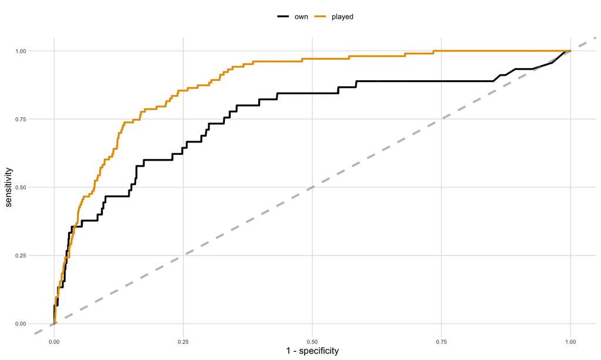

Another way to think about the model performance is to view its lift, or its ability to detect the positive outcomes over that of a null model. High lift indicates the model can much more quickly find all of the positive outcomes (in this case, games owned or played by the user), while a model with no lift is no better than random guessing.

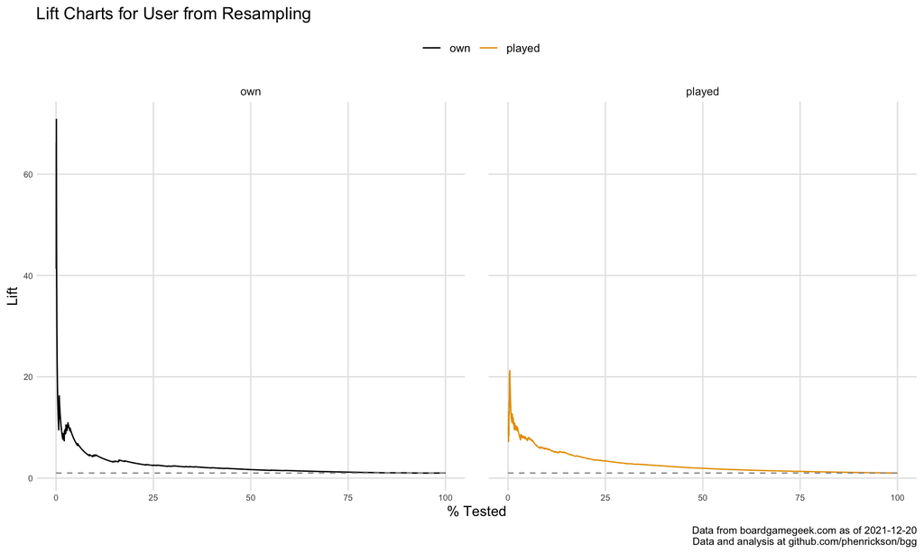

## 3.3 Most and Least Likely Games

What games does the model think hej989 is **most likely to own** that are **not** in their collection?

| username | yearpublished | game_id | name | pred_own | actual_own |
| --- | --- | --- | --- | --- | --- |
| hej989 | 2019 | 283863 | The Magnificent | 0.73 | 0 |
| hej989 | 2018 | 244711 | Newton | 0.45 | 0 |
| hej989 | 2018 | 199792 | Everdell | 0.37 | 0 |
| hej989 | 2014 | 146886 | La Granja | 0.25 | 0 |
| hej989 | 2019 | 281259 | The Isle of Cats | 0.23 | 0 |

What games does the model think hej989 is **least likely to own** that **are** in their collection?

| username | yearpublished | game_id | name | pred_own | actual_own |
| --- | --- | --- | --- | --- | --- |
| hej989 | 2017 | 197405 | Tak | 0 | 1 |
| hej989 | 2009 | 54043 | Jaipur | 0 | 1 |
| hej989 | 2014 | 160477 | Onitama | 0 | 1 |
| hej989 | 2017 | 215840 | Exit: The Game – The Forbidden Castle | 0 | 1 |
| hej989 | 2017 | 217372 | The Quest for El Dorado | 0 | 1 |

## 3.4 Top Games by Year

Top 25 games most likely to be owned by the user in each year, highlighting in blue the games that the user has owned/played.

| rank | 2011 | 2012 | 2013 | 2014 | 2015 | 2016 | 2017 | 2018 | 2019 |
| --- | --- | --- | --- | --- | --- | --- | --- | --- | --- |
| 1 | Tragedy Looper | The Manhattan Project | Brew Crafters | La Granja | The Pursuit of Happiness | Terraforming Mars | Gaia Project | Newton | The Magnificent |
| 2 | Flash Point: Fire Rescue | Kairo | Sushi Go! | Deception: Murder in Hong Kong | The King Is Dead | The Networks | Magic Maze | Everdell | Barrage |
| 3 | Mage Knight Board Game | Terra Mystica | Castle Dice | Camel Up | My Village | Inis | Paper Tales | Rising Sun | The Isle of Cats |
| 4 | Mundus Novus | Seasons | Concept | Patchwork | Coffee Roaster | Roll Player | Sagrada | Underwater Cities | Era: Medieval Age |
| 5 | Sekigahara: The Unification of Japan | Among the Stars | Legacy: The Testament of Duke de Crecy | Imperial Settlers | Blood Rage | When I Dream | Pendragon: The Fall of Roman Britain | Sprawlopolis | Yukon Airways |
| 6 | Revolver | Robinson Crusoe: Adventures on the Cursed Island | Tajemnicze Domostwo | Fields of Arle | The Bloody Inn | La Granja: No Siesta | Calimala | The Grizzled: Armistice Edition | Old West Empresario |
| 7 | Laser Chess | Keyflower | Impulse | Sheep & Thief | Best Treehouse Ever | A Feast for Odin | Bunny Kingdom | Key Flow | Amul |
| 8 | Drako: Dragon & Dwarves | The Great Zimbabwe | Bomb Squad | Praetor | The Voyages of Marco Polo | The Oregon Trail Card Game | Codenames: Duet | Forum Trajanum | Clank!: Legacy – Acquisitions Incorporated |
| 9 | Friday | In Magnificent Style: Pickett's Charge at Gettysburg | Lewis & Clark: The Expedition | Spyfall | New Salem | Sushi Go Party! | Azul | Planet | Minecraft: Builders & Biomes |
| 10 | Martian Dice | War of the Ring: Second Edition | Pathfinder Adventure Card Game: Rise of the Runelords – Base Set | Istanbul | Mysterium | Capital Lux | Dungeon Draft | Dice Hospital | Aquatica |
| 11 | Ventura | Wiz-War (Eighth Edition) | Coal Baron | Five Tribes | Nevermore | Islebound | Pulsar 2849 | Blue Lagoon | Tiny Towns |
| 12 | Principato | Il Vecchio | Gravwell: Escape from the 9th Dimension | Nations: The Dice Game | FUSE | Yokohama | Pocket Mars | Fuji | Last Bastion |
| 13 | Pantheon | Legendary: A Marvel Deck Building Game | Wildcatters | Ultimate Werewolf | ...and then, we held hands. | Coal Baron: The Great Card Game | Harvest Dice | That's Pretty Clever! | Maracaibo |
| 14 | Singapore | Tokaido | Dungeon Roll | Power Grid Deluxe: Europe/North America | Between Two Cities | Hit Z Road | Codenames: Marvel | Brass: Birmingham | It's a Wonderful World |
| 15 | Village | CO₂ | Forbidden Desert | Spurs: A Tale in the Old West | The Grizzled | Agricola (Revised Edition) | Codenames: Disney – Family Edition | Cahoots | Carnival of Monsters |
| 16 | Gears of War: The Board Game | Mage Wars Arena | Smash Up: Awesome Level 9000 | Legendary Encounters: An Alien Deck Building Game | Raptor | Assembly | Muse | Sherlock: Last Call | Queenz: To Bee or Not to Bee |
| 17 | Urban Sprawl | Targi | Smash Up: The Obligatory Cthulhu Set | Medieval Academy | Haspelknecht | Kingdomino | Mountains of Madness | Belratti | Wingspan |
| 18 | Ora et Labora | Pocket Battles: Macedonians vs. Persians | The Ravens of Thri Sahashri | Heroes of Normandie | 504 | Codenames: Deep Undercover | The Shipwreck Arcana | Architects of the West Kingdom | Freshwater Fly |
| 19 | Space Empires: 4X | Pixel Tactics | Hoplomachus: Rise of Rome | Smash Up: Science Fiction Double Feature | Grand Austria Hotel | Okey Dokey | Sentient | Duelosaur Island | Azul: Summer Pavilion |
| 20 | Santiago de Cuba | Le Havre: The Inland Port | Le Fantôme de l'Opéra | Smash Up: Monster Smash | Food Chain Magnate | Aeon's End | Lisboa | Coimbra | The Towers of Arkhanos |
| 21 | Discworld: Ankh-Morpork | Polis: Fight for the Hegemony | Navajo Wars | Saboteur: The Duel | Tiny Epic Galaxies | Clank!: A Deck-Building Adventure | Clans of Caledonia | CO₂: Second Chance | Twice as Clever! |
| 22 | Pastiche | Equinox | The Hunters: German U-Boats at War, 1939-43 | oddball Äeronauts | SteamRollers | The Dragon & Flagon | Noria | Street Masters | Noctiluca |
| 23 | Shitenno | Okiya | Longhorn | Haru Ichiban | Wing Leader: Victories 1940-1942 | Broom Service: The Card Game | Queendomino | Teotihuacan: City of Gods | Remember Our Trip |
| 24 | Coney Island | Empire Express | Cruel Necessity: The English Civil Wars 1640-1653 | Hapsburg Eclipse | Smash Up: Pretty Pretty Smash Up | Junk Art | Mint Delivery | The Little Flower Shop | Pipeline |
| 25 | Siberia | Star Trek Deck Building Game: The Original Series | Infection: Humanity's Last Gasp | Elevenses for One | The Dwarves: The Duel | Mythos Tales | 13 Minutes: The Cuban Missile Crisis, 1962 | Western Legends | Trismegistus: The Ultimate Formula |

## 3.5 Interactive Predictions from Resampling

Interactive table for predictions from resampling.

|  | username | yearpublished | rank | game_id | name | pred_played | pred_own | actual_played | actual_own |
| --- | --- | --- | --- | --- | --- | --- | --- | --- | --- |
| 1 | hej989 | 1900 | 256 | 188 | Go | 0.01 | 0.01 | 0 | 0 |
| 2 | hej989 | 1900 | 273 | 171 | Chess | 0.01 | 0.01 | 0 | 0 |
| 3 | hej989 | 1900 | 277 | 2065 | Shogi | 0.01 | 0.01 | 0 | 0 |
| 4 | hej989 | 1900 | 312 | 26952 | International Checkers | 0.01 | 0.01 | 0 | 0 |
| 5 | hej989 | 1900 | 315 | 2083 | Checkers | 0.01 | 0.01 | 0 | 0 |
| 6 | hej989 | 1900 | 317 | 2389 | Othello | 0.01 | 0.01 | 0 | 0 |
| 7 | hej989 | 1900 | 369 | 10213 | Fox and Geese | 0.01 | 0.01 | 0 | 0 |
| 8 | hej989 | 1900 | 438 | 10400 | Patience | 0.01 | 0.01 | 0 | 0 |
| 9 | hej989 | 1900 | 682 | 2173 | 4 Player Chess | 0.01 | 0.01 | 0 | 0 |
| 10 | hej989 | 1900 | 793 | 38950 | Halma | 0.01 | 0.01 | 0 | 0 |

[output cut: 7426 more lines]

# 4 Validating the Model on 2020

How well did a model trained on a user’s collection through 2019 perform in predicting games for the user from 2020?

| username | outcome_type | yearpublished | .metric | .estimator | .estimate |
| --- | --- | --- | --- | --- | --- |
| hej989 | own | 2020 | roc_auc | binary | 0.747 |
| hej989 | played | 2020 | roc_auc | binary | 0.838 |

Table of top 25 games from 2020, highlighting games that the user owns.

| username | yearpublished | game_id | name | pred_own | pred_played | actual_own | actual_played |
| --- | --- | --- | --- | --- | --- | --- | --- |
| hej989 | 2020 | 184267 | On Mars | 0.30 | 0.62 | 0 | 0 |
| hej989 | 2020 | 297204 | Traintopia | 0.19 | 0.21 | 0 | 0 |
| hej989 | 2020 | 297030 | Tekhenu: Obelisk of the Sun | 0.15 | 0.25 | 0 | 0 |
| hej989 | 2020 | 299960 | Alma Mater | 0.09 | 0.11 | 0 | 0 |
| hej989 | 2020 | 300322 | Hallertau | 0.09 | 0.18 | 0 | 0 |
| hej989 | 2020 | 307844 | Atheneum: Mystic Library | 0.09 | 0.19 | 0 | 0 |
| hej989 | 2020 | 317231 | Monasterium | 0.07 | 0.07 | 0 | 0 |
| hej989 | 2020 | 270143 | Kōhaku | 0.06 | 0.04 | 0 | 0 |
| hej989 | 2020 | 298130 | Amalfi | 0.06 | 0.05 | 0 | 0 |
| hej989 | 2020 | 311193 | Anno 1800 | 0.06 | 0.36 | 0 | 0 |
| hej989 | 2020 | 291457 | Gloomhaven: Jaws of the Lion | 0.05 | 0.27 | 0 | 0 |
| hej989 | 2020 | 298017 | Treelings | 0.05 | 0.04 | 0 | 0 |
| hej989 | 2020 | 302465 | Obsidia | 0.05 | 0.07 | 0 | 0 |
| hej989 | 2020 | 307002 | Regicide | 0.05 | 0.07 | 0 | 0 |
| hej989 | 2020 | 308765 | Praga Caput Regni | 0.05 | 0.21 | 1 | 1 |
| hej989 | 2020 | 319966 | The King Is Dead: Second Edition | 0.05 | 0.06 | 0 | 0 |
| hej989 | 2020 | 267009 | Rome & Roll | 0.04 | 0.03 | 0 | 0 |
| hej989 | 2020 | 271002 | Myraclia | 0.04 | 0.05 | 0 | 0 |
| hej989 | 2020 | 288513 | Tranquility | 0.04 | 0.06 | 0 | 0 |
| hej989 | 2020 | 292333 | Cowboys II: Cowboys & Indians Edition | 0.04 | 0.16 | 0 | 0 |
| hej989 | 2020 | 292487 | 10 Gallon Tank | 0.04 | 0.03 | 0 | 0 |
| hej989 | 2020 | 298271 | Cutterland | 0.04 | 0.03 | 0 | 0 |
| hej989 | 2020 | 298371 | Wild Space | 0.04 | 0.08 | 0 | 0 |
| hej989 | 2020 | 298618 | Hatairo | 0.04 | 0.03 | 0 | 0 |
| hej989 | 2020 | 316377 | 7 Wonders (Second Edition) | 0.04 | 0.08 | 0 | 0 |

# 5 Predicting Upcoming Games (2020 and On) for **hej989**

Examine the top games for the test set.

| username | yearpublished | game_id | name | rank | own | played |
| --- | --- | --- | --- | --- | --- | --- |
| hej989 | 2020 | 184267 | On Mars | 1 | 0.30 | 0.62 |
| hej989 | 2020 | 297204 | Traintopia | 2 | 0.19 | 0.21 |
| hej989 | 2020 | 297030 | Tekhenu: Obelisk of the Sun | 3 | 0.15 | 0.25 |
| hej989 | 2020 | 299960 | Alma Mater | 4 | 0.09 | 0.11 |
| hej989 | 2020 | 307844 | Atheneum: Mystic Library | 5 | 0.09 | 0.19 |
| hej989 | 2020 | 300322 | Hallertau | 6 | 0.09 | 0.18 |
| hej989 | 2020 | 317231 | Monasterium | 7 | 0.07 | 0.07 |
| hej989 | 2020 | 270143 | Kōhaku | 8 | 0.06 | 0.04 |
| hej989 | 2020 | 311193 | Anno 1800 | 9 | 0.06 | 0.36 |
| hej989 | 2020 | 298130 | Amalfi | 10 | 0.06 | 0.05 |
| hej989 | 2020 | 307002 | Regicide | 11 | 0.05 | 0.07 |
| hej989 | 2020 | 308765 | Praga Caput Regni | 12 | 0.05 | 0.21 |
| hej989 | 2020 | 302465 | Obsidia | 13 | 0.05 | 0.07 |
| hej989 | 2020 | 291457 | Gloomhaven: Jaws of the Lion | 14 | 0.05 | 0.27 |
| hej989 | 2020 | 298017 | Treelings | 15 | 0.05 | 0.04 |
| hej989 | 2020 | 319966 | The King Is Dead: Second Edition | 16 | 0.05 | 0.06 |
| hej989 | 2020 | 288513 | Tranquility | 17 | 0.04 | 0.06 |
| hej989 | 2020 | 292487 | 10 Gallon Tank | 18 | 0.04 | 0.03 |
| hej989 | 2020 | 298618 | Hatairo | 19 | 0.04 | 0.03 |
| hej989 | 2020 | 298271 | Cutterland | 20 | 0.04 | 0.03 |
| hej989 | 2020 | 316622 | Gods Love Dinosaurs | 21 | 0.04 | 0.03 |
| hej989 | 2020 | 267009 | Rome & Roll | 22 | 0.04 | 0.03 |
| hej989 | 2020 | 316377 | 7 Wonders (Second Edition) | 23 | 0.04 | 0.08 |
| hej989 | 2020 | 298371 | Wild Space | 24 | 0.04 | 0.08 |
| hej989 | 2020 | 292333 | Cowboys II: Cowboys & Indians Edition | 25 | 0.04 | 0.16 |
| hej989 | 2021 | 298102 | Roll Camera!: The Filmmaking Board Game | 1 | 0.31 | 0.65 |
| hej989 | 2021 | 310873 | Carnegie | 2 | 0.23 | 0.44 |
| hej989 | 2021 | 315624 | World Changers | 3 | 0.13 | 0.12 |
| hej989 | 2021 | 343905 | Boonlake | 4 | 0.13 | 0.32 |
| hej989 | 2021 | 295947 | Cascadia | 5 | 0.13 | 0.14 |
| hej989 | 2021 | 342942 | Ark Nova | 6 | 0.13 | 0.44 |
| hej989 | 2021 | 291847 | Mantis Falls | 7 | 0.11 | 0.29 |
| hej989 | 2021 | 319999 | Dungeon Decorators | 8 | 0.10 | 0.17 |
| hej989 | 2021 | 309408 | Arcana Rising | 9 | 0.09 | 0.09 |
| hej989 | 2021 | 301018 | Dragon Parks | 10 | 0.09 | 0.09 |
| hej989 | 2021 | 291859 | Riftforce | 11 | 0.09 | 0.41 |
| hej989 | 2021 | 320992 | The Specialists | 12 | 0.08 | 0.09 |
| hej989 | 2021 | 322588 | Origins: First Builders | 13 | 0.08 | 0.11 |
| hej989 | 2021 | 252752 | Genotype: A Mendelian Genetics Game | 14 | 0.07 | 0.09 |
| hej989 | 2021 | 314589 | Night Parade of a Hundred Yokai | 15 | 0.06 | 0.05 |
| hej989 | 2021 | 314088 | Agropolis | 16 | 0.06 | 0.11 |
| hej989 | 2021 | 301441 | Drawn to Adventure | 17 | 0.06 | 0.06 |
| hej989 | 2021 | 344277 | Corrosion | 18 | 0.05 | 0.05 |
| hej989 | 2021 | 293404 | Public Market | 19 | 0.04 | 0.03 |
| hej989 | 2021 | 295221 | With A Smile & A Gun | 20 | 0.04 | 0.03 |
| hej989 | 2021 | 307170 | El Valle Secreto | 21 | 0.04 | 0.03 |
| hej989 | 2021 | 310632 | Dice Miner | 22 | 0.04 | 0.03 |
| hej989 | 2021 | 322421 | Aqua Garden | 23 | 0.04 | 0.03 |
| hej989 | 2021 | 329641 | King of the Pitch | 24 | 0.04 | 0.03 |
| hej989 | 2021 | 275213 | 7 Summits | 25 | 0.04 | 0.03 |
| hej989 | 2022 | 334065 | Verdant | 1 | 0.14 | 0.16 |
| hej989 | 2022 | 319807 | Shogun no Katana | 2 | 0.11 | 0.11 |
| hej989 | 2022 | 317511 | Tindaya | 3 | 0.06 | 0.31 |
| hej989 | 2022 | 295770 | Frosthaven | 4 | 0.05 | 0.15 |
| hej989 | 2022 | 331401 | Dog Park | 5 | 0.02 | 0.04 |
| hej989 | 2022 | 295374 | Long Shot: The Dice Game | 6 | 0.02 | 0.10 |
| hej989 | 2022 | 338067 | 6: Siege – The Board Game | 7 | 0.02 | 0.05 |
| hej989 | 2022 | 324090 | Scarface 1920 | 8 | 0.02 | 0.05 |
| hej989 | 2022 | 335427 | Wild: Serengeti | 9 | 0.02 | 0.05 |
| hej989 | 2022 | 299106 | Fractal: Beyond the Void | 10 | 0.02 | 0.05 |
| hej989 | 2022 | 305096 | Endless Winter: Paleoamericans | 11 | 0.02 | 0.05 |
| hej989 | 2022 | 295895 | Distilled | 12 | 0.02 | 0.02 |
| hej989 | 2022 | 256680 | Return to Dark Tower | 13 | 0.02 | 0.08 |
| hej989 | 2022 | 280726 | Legacies | 14 | 0.02 | 0.06 |
| hej989 | 2022 | 304051 | Creature Comforts | 15 | 0.02 | 0.07 |
| hej989 | 2022 | 331106 | The Witcher: Old World | 16 | 0.02 | 0.29 |
| hej989 | 2022 | 345868 | Federation | 17 | 0.02 | 0.05 |
| hej989 | 2022 | 311823 | Nova Aetas Renaissance | 18 | 0.01 | 0.03 |
| hej989 | 2022 | 271601 | Feed the Kraken | 19 | 0.01 | 0.02 |
| hej989 | 2022 | 281258 | Sub Terra II: Inferno's Edge | 20 | 0.01 | 0.03 |
| hej989 | 2022 | 273814 | Deliverance | 21 | 0.01 | 0.04 |
| hej989 | 2022 | 283137 | Human Punishment: The Beginning | 22 | 0.01 | 0.02 |
| hej989 | 2022 | 240980 | Blood on the Clocktower | 23 | 0.01 | 0.01 |
| hej989 | 2022 | 312859 | Townsfolk Tussle | 24 | 0.01 | 0.02 |
| hej989 | 2022 | 219650 | Arydia: The Paths We Dare Tread | 25 | 0.01 | 0.02 |

## 5.1 Interactive Table for Upcoming Games 2020 and On

|  | username | yearpublished | game_id | name | rank | own | played |
| --- | --- | --- | --- | --- | --- | --- | --- |
| 1 | hej989 | 2021 | 298102 | Roll Camera!: The Filmmaking Board Game | 1 | 0.31 | 0.65 |
| 2 | hej989 | 2020 | 184267 | On Mars | 2 | 0.3 | 0.62 |
| 3 | hej989 | 2021 | 310873 | Carnegie | 3 | 0.23 | 0.44 |
| 4 | hej989 | 2020 | 297204 | Traintopia | 4 | 0.19 | 0.21 |
| 5 | hej989 | 2020 | 297030 | Tekhenu: Obelisk of the Sun | 5 | 0.15 | 0.25 |
| 6 | hej989 | 2022 | 334065 | Verdant | 6 | 0.14 | 0.16 |
| 7 | hej989 | 2021 | 315624 | World Changers | 7 | 0.13 | 0.12 |
| 8 | hej989 | 2021 | 343905 | Boonlake | 8 | 0.13 | 0.32 |
| 9 | hej989 | 2021 | 295947 | Cascadia | 9 | 0.13 | 0.14 |
| 10 | hej989 | 2021 | 342942 | Ark Nova | 10 | 0.13 | 0.44 |

[output cut: 1627 more lines]